# Final Exam

Data 180, Professor Kennedy

HyunYoung Cho

chohy@dickinson.edu

December 10, 2023

**Due date:** December 15th at 11:59 pm EST.

# Question 1 - Data wrangling:

1. What is the dimension (shape) of the dataset? How many rows and columns does the data set have?

```r
loan_default_data <- read.csv("/Users/young/Documents/college/dickinson/2023-2024/data_HyunYoung/HyunYoung_data180/final_exam/loan_default_data_set.csv")

dataset_dimension <- dim(loan_default_data)
rows <- dataset_dimension[1]
columns <- dataset_dimension[2]

#The dimension of the dataset given is 20000 x 21 (n x p). The data set has 20000 rows and 21 columns.
```

2. Report the column names of the data set.

```r
column_names <- colnames(loan_default_data)

cat("The column names of the dataset are:", paste(column_names, collapse = ", "), "\n")
```

[output not shown]

3. Which types of data are there in the dataset? Numeric, categorical, ordinal?

```r
#The types of data present in the dataset include numeric(quantitative), and categorical(qualitative)-ordinal data types. The numeric(quantitative) data type, which is a variable that measures a numerical characteristics can be found in the dataset: tot_balance, avg_bal_cards, credit_age, and etc. The ordinal data type from categorical(qualitative) represents the variables that classifies the unites into categories and have a natural ordering to them. The examples of ordinal data from categorical(qualitative) data types can be found as following: high_school, college, and graduate. Thus, there are numerical and categorical - ordinal data types present in the dataset.
```

4. Which columns contain missing values and how much (what percent) of those columns are missing?

```r
loan_default_data <- read.csv("/Users/young/Documents/college/dickinson/2023-2024/data_HyunYoung/HyunYoung_data180/final_exam/loan_default_data_set.csv")

missing_columns <- colnames(loan_default_data)[colSums(is.na(loan_default_data)) > 0]
missing_percentages <- colSums(is.na(loan_default_data[, missing_columns])) / nrow(loan_default_data) * 100

cat("Columns with missing values and their respective percentages:\n")
```

```
## Columns with missing values and their respective percentages:
```

```r
for (i in seq_along(missing_columns)) {
  cat(missing_columns[i], ":", missing_percentages[i], "%\n")
}
```

```
## pct_card_over_50_uti : 9.79 %
## rep_income : 7.795 %
```

```r
#The columns which contain missing values are 'pct_card_over_50_uti' and 'rep_income'. The percentage of the column 'pct_card_over_50_uti' is 9.79%, and the percentage of the column 'rep_income' is 7.795%.
```

5. How do you think we should deal with missing values?

```r
#There are several strategies to deal with missing values. First of all, we can impute the missing values with the mean, median, or mode in the column, which helps maintaining the size of the dataset while filling in the missing values in the column. For example, we can impute the missing values in a numeric column with the mean by using following code: "loan_default_data$numeric_column[is.na(loan_default_data$numeric_column)] <- mean(loan_default_data$numeric_column, na.rm = TRUE)". Secondly, we can omit the rows with missing values if the number of rows with missing values is relatively small and doesn't significantly impact or change the dataset. The following method can be done by using na.omit() function. Thirdly, we can create a missing indicator by creating a new binary column, which represents whether a value was missing in the original column. Through this, we can preserve information about the missing value in the column. Finally, there is a method using an advanced imputation method with multiple imputation or machine learning-based methods. This method predicts the missing values by using other variables in the dataset and fills the missing values in the column.
```

6. With this data, would you fit a supervised or an unsupervised learning model? Why?

```r
#With this data, supervised learning model would fit more likely than unsupervised learning model. This is because this loan default dataset given represents the historical data containing binary response and predictor variables from credit card accounts for bank XYZ, which correspond to the object and goal of supervised learning model. Supervised learning can be used when there are observations that is composed of predictor and response variables. Since the primary goal of supervised learning is to utilize the relationship between the predictor and response variables for prediction and inference based on the observations. One of examples of supervised learning algorithms include regression for predicting numerical values and classification for predicting categorical outcomes. Therefore, this loan default dataset fits with supervised learning model since it has predictor and response variables for prediction and inference based on the observations.
```

7. For part 2 and 3 drop all rows of the data that contain missing values. Print the dimensions of the resulting data set that has no missing values.

```r
loan_default_data_no_missing <- na.omit(loan_default_data)

dataset_dimension_no_missing <- dim(loan_default_data_no_missing)
rows_no_missing <- dataset_dimension_no_missing[1]
columns_no_missing <- dataset_dimension_no_missing[2]

cat("The dimension of the dataset with no missing values is:", rows_no_missing, "rows and", columns_no_missing, "columns.")
```

```
## The dimension of the dataset with no missing values is: 16653 rows and 21 columns.
```

# Question 2 - Data summary statistics:

1. Find the summary statistics of the data set. You can use the summary function from dplyr.

```r
#install.packages("dplyr")
library(dplyr)
summary_statistics <- summary(loan_default_data_no_missing)
summary_statistics
```

```
##   tot_balance     avg_bal_cards     credit_age    credit_age_good_account
##  Min.   :     0   Min.   :    0   Min.   :  0.0   Min.   :  0.0
##  1st Qu.: 92142   1st Qu.:10135   1st Qu.:231.0   1st Qu.:120.0
##  Median :107740   Median :12237   Median :281.0   Median :146.0
##  Mean   :107503   Mean   :12226   Mean   :280.9   Mean   :146.2
##  3rd Qu.:122932   3rd Qu.:14297   3rd Qu.:330.0   3rd Qu.:172.0
##  Max.   :200000   Max.   :25000   Max.   :550.0   Max.   :300.0
##  credit_card_age num_acc_30d_past_due_12_months num_acc_30d_past_due_6_months
##  Min.   :  0.0   Min.   :0.0000                 Min.   :0.00000
##  1st Qu.:242.0   1st Qu.:0.0000                 1st Qu.:0.00000
##  Median :285.0   Median :0.0000                 Median :0.00000
##  Mean   :285.4   Mean   :0.1579                 Mean   :0.02936
##  3rd Qu.:330.0   3rd Qu.:0.0000                 3rd Qu.:0.00000
##  Max.   :550.0   Max.   :5.0000                 Max.   :2.00000
##  num_mortgage_currently_past_due tot_amount_currently_past_due
##  Min.   :0.0000                  Min.   :    0.0
##  1st Qu.:0.0000                  1st Qu.:    0.0
##  Median :0.0000                  Median :    0.0
##  Mean   :0.0299                  Mean   :  354.2
##  3rd Qu.:0.0000                  3rd Qu.:    0.0
##  Max.   :1.0000                  Max.   :35000.0
##  num_inq_12_month  num_card_inq_24_month num_card_12_month num_auto_.36_month
##  Min.   : 0.0000   Min.   : 0.000        Min.   :0.0000    Min.   :0.000
##  1st Qu.: 0.0000   1st Qu.: 0.000        1st Qu.:0.0000    1st Qu.:0.000
##  Median : 0.0000   Median : 0.000        Median :0.0000    Median :0.000
##  Mean   : 0.6133   Mean   : 1.044        Mean   :0.2723    Mean   :0.165
##  3rd Qu.: 1.0000   3rd Qu.: 1.000        3rd Qu.:1.0000    3rd Qu.:0.000
##  Max.   :10.0000   Max.   :18.000        Max.   :3.0000    Max.   :2.000
##  uti_open_card    pct_over_50_uti  uti_max_credit_line pct_card_over_50_uti
##  Min.   :0.0000   Min.   :0.0000   Min.   :0.0000      Min.   :0.0000
##  1st Qu.:0.4048   1st Qu.:0.4011   1st Qu.:0.3778      1st Qu.:0.4643
##  Median :0.4909   Median :0.4855   Median :0.4649      Median :0.5518
##  Mean   :0.4914   Mean   :0.4842   Mean   :0.4653      Mean   :0.5511
##  3rd Qu.:0.5783   3rd Qu.:0.5679   3rd Qu.:0.5541      3rd Qu.:0.6384
##  Max.   :1.0000   Max.   :0.9294   Max.   :1.0000      Max.   :1.0000
##     ind_XYZ         rep_income     rep_education         Def_ind
##  Min.   :0.0000   Min.   : 20000   Length:16653       Min.   :0.0000
##  1st Qu.:0.0000   1st Qu.:143751   Class :character   1st Qu.:0.0000
##  Median :0.0000   Median :166630   Mode  :character   Median :0.0000
##  Mean   :0.2487   Mean   :166504                      Mean   :0.1019
##  3rd Qu.:0.0000   3rd Qu.:189020                      3rd Qu.:0.0000
##  Max.   :1.0000   Max.   :300000                      Max.   :1.0000
```

2. Based on the mean, mode, and median, is “num_card_inq_24_month” bell shaped, left, right skewed? How about “tot_amount_currently_past_due”? “credit_age”?

```r
Mode <- function(x) {
  ux <- unique(x)
  ux[which.max(tabulate(match(x, ux)))]
}

variable_names <- c("num_card_inq_24_month", "tot_amount_currently_past_due", "credit_age")

determine_skewness <- function(variable, variable_name) {
  mean_value <- mean(variable)
  median_value <- median(variable)
  mode_value <- Mode(variable)

  cat("Variable:", variable_name, "\n")
  cat("Mean:", mean_value, ", Median:", median_value, ", Mode:", mode_value, "\n", "\n")
}

for (variable_name in variable_names) {
  determine_skewness(loan_default_data_no_missing[[variable_name]], variable_name)
}
```

```
## Variable: num_card_inq_24_month
## Mean: 1.043896 , Median: 0 , Mode: 0
##
## Variable: tot_amount_currently_past_due
## Mean: 354.1857 , Median: 0 , Mode: 0
##
## Variable: credit_age
## Mean: 280.8684 , Median: 281 , Mode: 295
##
```

```r
#For 'num_card_inq_24_month' variable, the mean is 1.044, median is 0, and mode is 0. Since the mean is bigger than median, 'num_card_inq_24_month' is right-skewed.
#For 'tot_amount_currently_past_due' variable, the mean is 354.2, median is 0, and mode is 0. Since the mean is bigger than median, 'tot_amount_currently_past_due' is right-skewed.
#For 'credit_age' variable, the mean is 280.9, median is 281.0, and mode is 295. Since the mean is approximately equal to median, 'credit_age' is approximately symmetric or bell-shaped.
```

3. Plot a histogram of the variables in b above. Do the shapes of the histograms confirm the skewness you found in b?

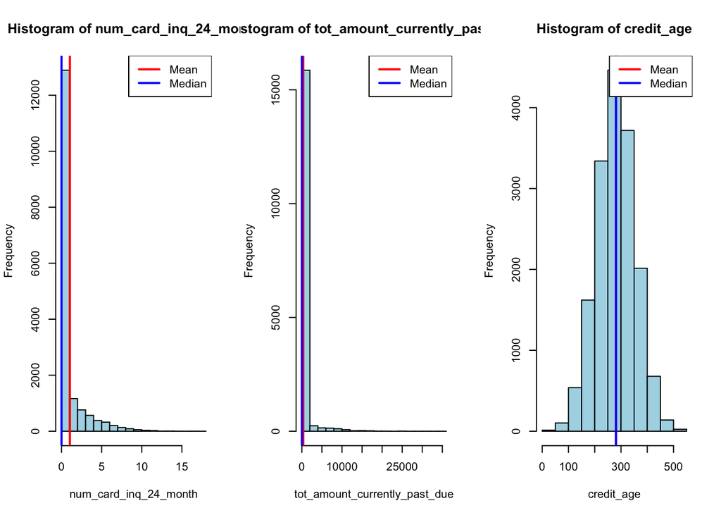

```r
variables_to_plot <- c("num_card_inq_24_month", "tot_amount_currently_past_due", "credit_age")


plot_histogram_and_skewness <- function(variable, variable_name) {
  hist(variable, main = paste("Histogram of", variable_name), xlab = variable_name, col = "lightblue", border = "black")
  abline(v = mean(variable), col = "red", lwd = 2)
  abline(v = median(variable), col = "blue", lwd = 2)
  legend("topright", legend = c("Mean", "Median"), col = c("red", "blue"), lwd = 2)
}

par(mfrow = c(1, 3))
for (variable_name in variables_to_plot) {
  plot_histogram_and_skewness(loan_default_data_no_missing[[variable_name]], variable_name)
}
```

```r
par(mfrow = c(1, 1))

# Yes, since the shape of the distribution for "num_card_inq_24_month" variable is right-skewed, "tot_amount_currently_past_due" variable is right-skewed, and "credit_age" variable is approximately symmetric or bell-shaped, the shapes of the histograms confirm the skewness I found in part b.
```

4. How would your convert the “rep_education” column into numerical data? Name two ways.

```r
#Natural Language Tool Kit(NLTK) and Term Frequency-Inverse Document Frequency(TF-IDF) methods can convert the "rep_education" column into numerical data. Natural Language Took Kit, which is a suite of libraries and programs for statistical natural language processing for English written in the programming supports classification, tokenization, and other semantic reasoning functionalities. Thus, NLTK method is one way to convert the "rep_education" column into numerical data. Also, Term Frequency-Inverse Document Frequency handles with a numerical statistic that is used to reflect and contain the importance of a text in a document relative to a collection of documents, considering both its frequency and rarity. Through TK-IDF tool, the "rep_education" column can be converted into numerical data based on the frequency and rarity of words in a document.

#Additionally, another method could be manually mapping the categories to numerical values using a predefined dictionary. For example, the following code can be used for manual mapping of categories to numerical values: education_mapping <- c("High School" = 1, "College" = 2, "Bachelor's" = 3, "Master's" = 4, "Doctorate" = 5). By creating a mapping dictionary, the "rep_education" column can be converted into numerical data, and this method is especially useful in "rep_education" column since this method can deal with ordinal relationship among categories, allowing to explicitly control the mapping.
```